# GV300 Showcase

Martha Sansom  
02-06-2026

# Introduction

This work demonstrates some of the code I have created during my final year Advanced Quantitative Political Analysis module.

# Code chunk

```r
library(tidyverse)

uk_csv <- "https://electionresults.parliament.uk/general-elections/6/candidacies.csv"
uk_raw <- readr::read_csv(uk_csv, show_col_types = FALSE)

names(uk_raw) <- names(uk_raw) %>% tolower() %>% str_replace_all("\\s+", "_")

uk1 <- uk_raw %>%
  filter(!`election_is_by-election`)

uk2 <- uk1 %>%
  select(
    constituency = constituency_name,
    country      = country_name,
    valid_votes  = candidate_vote_count,
    electorate   = electorate
  )

uk3 <- uk2 %>%
  group_by(country, constituency) %>%
  summarise(
    valid_votes = sum(valid_votes, na.rm = TRUE),
    electorate  = max(electorate, na.rm = TRUE),
    .groups = "drop"
  )

uk <- uk3 %>%
  mutate(turnout_registered = 100 * valid_votes / electorate) %>%
  filter(is.finite(turnout_registered), electorate > 0)

non_voter_analysis <- uk %>%
  mutate(non_voters = electorate - valid_votes)

total_non_voters <- sum(non_voter_analysis$non_voters)
total_electorate <- sum(non_voter_analysis$electorate)
total_voters <- sum(non_voter_analysis$valid_votes)
non_voter_percentage <- 100 * total_non_voters / total_electorate

top_non_voters <- non_voter_analysis %>%
  arrange(desc(non_voters)) %>%
  slice_head(n = 10) %>%
  select(constituency, country, electorate, valid_votes,
         non_voters, turnout_registered)

top_non_voters
```

```
# A tibble: 10 × 6
   constituency              country electorate valid_votes non_voters
   <chr>                     <chr>        <dbl>       <dbl>      <dbl>
 1 Birmingham Ladywood       England      83693       36579      47114
 2 Manchester Central        England      85204       39725      45479
 3 Leeds South               England      75953       31678      44275
 4 Wolverhampton South East  England      77473       33382      44091
 5 Salford                   England      83633       39704      43929
 6 Birmingham Hodge Hill an… England      77737       34136      43601
 7 Manchester Rusholme       England      72608       29033      43575
 8 Barking                   England      79822       36477      43345
 9 Birmingham Erdington      England      77463       34137      43326
10 Bolton South and Walkden  England      79622       36930      42692
# ℹ 1 more variable: turnout_registered <dbl>
```

# Visualisation

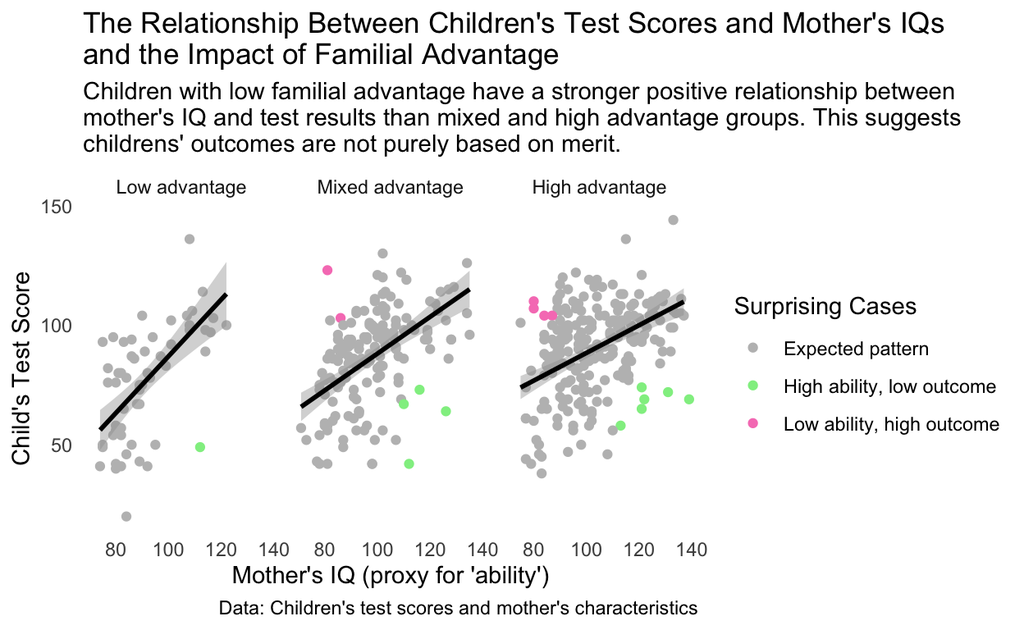

```r
library(dplyr)
library(ggplot2)
library(readr)
library(here)
kidiq <- read_csv(here::here("_data", "kidiq-2.csv"))

kidiq <- kidiq %>%
  mutate(
    ability_level = case_when(
      mom_iq <= quantile(mom_iq, 0.25, na.rm = TRUE) ~ "Low ability",
      mom_iq <= quantile(mom_iq, 0.75, na.rm = TRUE) ~ "Medium ability",
      TRUE ~ "High ability"
    ),
     outcome_level = case_when(
      kid_score <= quantile(kid_score, 0.25, na.rm = TRUE) ~ "Low outcome",
      kid_score <= quantile(kid_score, 0.75, na.rm = TRUE) ~ "Medium outcome",
      TRUE ~ "High outcome"
    ),
    iq_group = case_when(
      mom_iq <= quantile(mom_iq, 0.33, na.rm = TRUE) ~ "Lower IQ",
      mom_iq <= quantile(mom_iq, 0.67, na.rm = TRUE) ~ "Middle IQ",
      TRUE ~ "Higher IQ"
    ),
    surprising_case = case_when(
      ability_level == "High ability" & outcome_level == "Low outcome" ~ "High ability, low outcome",
      ability_level == "Low ability" & outcome_level == "High outcome" ~ "Low ability, high outcome",
      TRUE ~ "Expected pattern"
    ),
        family_advantage = case_when(
      mom_hs == 0 & mom_work <= 2 ~ "Low advantage",
      mom_hs == 0 & mom_work > 2 ~ "Mixed advantage",
      mom_hs == 1 & mom_work <= 2 ~ "Mixed advantage",
      mom_hs == 1 & mom_work > 2 ~ "High advantage"
    ),
    mom_round_iq = round(kidiq $ mom_iq, digits = 0)
  )

# this reorders levels of advantage to a logical order of low, mixed, and high.
kidiq $ family_advantage <- factor(kidiq $ family_advantage, levels = c("Low advantage", "Mixed advantage",
                                                                        "High advantage"))

# this reorders levels of mom IQ to a logical order of lower, middle, and high.
kidiq $ iq_group <- factor(kidiq $ iq_group, levels = c("Lower IQ", "Middle IQ", "Higher IQ"))

 kidiq %>%
  ggplot(aes(x = mom_round_iq, y = kid_score, color = surprising_case)) +
  geom_point() +
  geom_smooth(data = subset(kidiq, surprising_case == "Expected pattern"),
              aes(x = mom_round_iq, y = kid_score),
              method = 'lm', color = "black") +
  facet_wrap(~ family_advantage) +
  scale_color_manual(values = c("Expected pattern" = "gray",
                               "High ability, low outcome" = "lightgreen",
                               "Low ability, high outcome" = "#F781BF"), name = "Surprising Cases") +
  labs(
    title = "The Relationship Between Children's Test Scores and Mother's IQs
and the Impact of Familial Advantage",
    subtitle = "Children with low familial advantage have a stronger positive relationship between
mother's IQ and test results than mixed and high advantage groups. This suggests
childrens' outcomes are not purely based on merit.",
    x = "Mother's IQ (proxy for 'ability')",
    y = "Child's Test Score",
    caption = "Data: Children's test scores and mother's characteristics"
  ) +
  theme_minimal() +
  theme(panel.grid.major = element_blank()) +
  theme(panel.grid.minor = element_blank())
```

# What the code does and what the figure shows.

After loading the data set, the first chunk of code creates meaningful categories, identifying: the level of the mother’s ability, the outcome level of children’s scores, groups the mothers by iq, identifies outliers, filters the mother’s by levels of advantage, and finally rounded the mother’s IQs. The following two lines of code reorder family advantage and mom IQ to make the visualisation follow a logical order (from low to high). The visualisation code displays the children’s test scores as points, whilst adding a regression line on top to show how the relationship between test scores and IQ vary across backgrounds. Surprising cases are coloured differently.

The figure shows that there is a positive relationship between mother’s IQ and child’s test score across all backgrounds. This means that children of mothers with higher IQ scores are more likely to test highly. This relationship is strongest in those with low familial advantage. The other two groups have more surprising cases (when the predicted relationship is not found) than low familial advantage but this may be due to them having larger sample sizes.

# Link to repository

https://github.com/martha-png/GV300-Assignment